# Informe Final

Rafael Graziani, Freddy Melgarejo, Salvador Nesta, Anselmo Velazco

2023-07-21

# El Real Madrid y la Champions League: El secreto de su dominio en el fútbol Europeo

[figure not shown]

## Introducción:

> El fútbol es uno de los deportes más populares y seguidos en todo el mundo. Por su parte, la UEFA Champions League es una competición en la que participan los mejores equipos de fútbol de Europa y es considerada una de las competiciones más importantes y prestigiosas a nivel mundial. Dentro de esta competición, el Real Madrid es uno de los equipos más exitosos en la historia, habiendo ganado el trofeo en múltiples ocasiones.

> El fútbol europeo ha sido testigo de la dominación del Real Madrid en la última década. Este equipo ha logrado un éxito sin precedentes en la UEFA Champions League, ganando cuatro títulos en cinco años y estableciéndose como uno de los mejores equipos de la historia del fútbol. En este informe, presentamos una investigación estadística para demostrar las razones detrás de este éxito y cómo el Real Madrid ha logrado dominar el fútbol europeo.

> La razón detrás de la gran cantidad de victorias del Real Madrid en la UEFA Champions League es un tema de interés no solo para los seguidores del fútbol, sino también para los analistas deportivos y los estrategas del deporte. El estudio del éxito del Real Madrid podría proporcionar información valiosa sobre los factores que contribuyen al éxito en el fútbol y se podría aplicar en otros equipos.

> Nuestra investigación se basa en el análisis de datos sobre el rendimiento del Real Madrid y otros equipos TOP de Europa como pueden ser el Barcelona, el Bayern, entre otros, durante la última década. A través de nuestro análisis estadístico, esperamos proporcionar una comprensión más profunda de las razones detrás de este éxito y ofrecer una perspectiva única sobre uno de los equipos más exitosos de la historia del fútbol.

> Además, el análisis de las estadísticas del Real Madrid podría dar lugar a la identificación de patrones y tendencias que permitan comprender mejor el éxito del equipo en la competición; permitiendo a otros equipos analizar su propio rendimiento en la UEFA Champions League y determinar las áreas en las que podrían mejorar.

> Por lo tanto, la justificación para abordar el tema propuesto es clara y relevante, ya que proporciona una oportunidad para comprender el éxito del equipo y del fútbol en general, así como para mejorar el rendimiento de otros equipos en la competición.

> Por último, el objetivo del análisis es poder responder interrogantes como:
> - ¿Por qué el Real Madrid gana tanto la UEFA Champions League?
> - ¿Las estadísticas del Real Madrid de los años en que ha ganado la competición, respaldan el logro del trofeo?
> - ¿El Real Madrid ha estado por encima de los otros competidores?, ¿o hay algunos equipos que según sus estadísticas, tenían que haber ganado el trofeo en vez del equipo español?

> Esperamos que este informe sea de interés para todos aquellos interesados en el fútbol y en el análisis estadístico del deporte.

[figure not shown]

**ADN Real Madrid: ¿A qué hace referencia? ¿si existe?**  
27 Junio. 2023 - 10:12 am  
Por: Iván Alba - @hableman

## Metodología:

> Para dar respuesta a las interrogantes planteadas en este proyecto, se utilizará una **metodología cuantitativa**, en la cual se hará un análisis comparativo y uno estadístico.

> El **análisis comparativo** implica la comparación de los datos del Real Madrid con los datos de otros equipos de fútbol que han participado en la UEFA Champions League. Este análisis permitirá identificar las fortalezas y debilidades del Real Madrid en comparación con otros equipos y determinar cómo el equipo se desempeña en diferentes situaciones de la competición. Para llevar a cabo el análisis comparativo, se utilizarán datos históricos de la UEFA Champions League y se compararán los registros del Real Madrid con los de otros equipos en diferentes estadísticas, como goles marcados, posesión de balón, tiros a puerta, entre otros.

> El **análisis estadístico** implica el uso de técnicas estadísticas para examinar los datos del Real Madrid en la UEFA Champions League y determinar patrones y tendencias en los datos. Se utilizarán diversas técnicas estadísticas para analizar los datos, como gráficas, el análisis de promedios, desviación de los datos y el análisis de correlación. Estas técnicas nos permitirán identificar las variables que tienen un mayor impacto en el éxito del Real Madrid en la competición y determinar cómo se relacionan estas variables entre sí.

> Para el análisis de las interrogantes planteadas se requerirá el uso de datos futbolísticos que reportan las estadísticas de cada equipo y en algunas ocasiones de los jugadores de los mismos. Es nuestro deber antes de comenzar con las visualizaciones de las gráficas, ayudar al lector a entender un poco los conceptos con los cuales se estarán trabajando. Entre estos, podemos mencionar:
> - Goles por partidos: se refieren al promedio de goles que marca un equipo por cada partido que juega. Este dato refleja la capacidad ofensiva de un equipo y su eficacia a la hora de aprovechar las oportunidades de gol.
> - Tiros, tiros a puerta y tiros fuera del objetivo: es el número de veces que un equipo dispara bien sea fuera o dentro del arco rival con intención de marcar gol. Estos datos ayudan a identificar el nivel de presión y peligro que genera un equipo sobre el contrario y su capacidad para crear ocasiones de gol.
> - Total de pases y pases completados: número de veces que un equipo logra conectar un pase con éxito a un compañero. Este concepto refleja el nivel de control del balón que tiene un equipo y su capacidad para mantener el ritmo y la fluidez del juego.
> - Posesión del balón: Es el porcentaje de tiempo que un equipo tiene el balón en su poder durante un partido. Refleja el nivel de dominio e iniciativa que tiene un equipo sobre el juego y su capacidad para imponer su estilo y estrategia.
> - Faltas cometidas y recibidas: es la cantidad de ocasiones en la que un equipo infringe o sufre una infracción por parte del contrario. Indica el nivel de agresividad y contacto físico que tiene un equipo y su capacidad para imponerse o resistir la presión del rival.
> - Dribles: veces en la que un jugador logra superar a un rival con el balón en su poder. Este dato indica el nivel de habilidad técnica y creatividad que tiene un jugador y su capacidad para generar situaciones de peligro y desequilibrio en el juego.
> - Salvadas: es la cantidad de veces en que un portero logra detener un disparo rival y evitar que entre en la portería. Muestra el nivel de seguridad y confianza que tiene un equipo en su guardameta y su capacidad para resistir la presión del ataque rival.

## Análisis:

[figure not shown]

```r
library(tidyverse) # Colección de paquetes para manipulación de datos.
library(dplyr) # Paquete para manipulación y transformación de datos.
library(readxl) # Paquete para leer datos de Excel.
library(ggthemes) # Temas, escalas y geoms adicionales para ggplot2.
library(ggplot2) # Paquete para crear visualizaciones elegantes de datos.
library(ggrepel) # Geoms para repeler etiquetas superpuestas en ggplot2.
library(knitr) # Motor para generar informes dinámicos con R.
library(gganimate)# Extensión de ggplot2 para crear animaciones.
library(reactablefmtr) # Mejora el estilo y el formato de las tablas.
library(reactable) # Crea tablas interactivas con ordenamiento y paginación.
library(ggsoccer) # Funciones para visualizar y explorar datos de fútbol.]
library(stringr)
library(reshape2)
```

> Para la creación de este informe se utilizó `knitr`, un motor para la generación de informes dinámicos con R que permite la integración de código R, resultados y texto en un solo documento. Esto facilita la creación de informes reproducibles y la comunicación de los análisis de datos.

> En cuanto al análisis de la data de la última decada de la UEFA Champions League para responder a las interrogantes planteadas previamente, se utilizó como paquete para el manejo de los datos la librería `tidyverse`, la cual permite producir datos reproducibles y manipular datos de forma más efectiva; como complemento también se trabajó con la librería `dplyr` que se encuentra dentro de `tidyverse` y proporciona más herramientas para manipular datos estructurados.

> Para poder abrir los archivos que contenían las bases de datos limpias, se necesitó la librería `readxl`. Una vez abiertas las librerías para la manipulación de datos, y la necesaria para visualizar los datos en sí, se cargaron también `ggthemes`, `ggplot2` y `ggrepel`, las cuales permiten representar gráficamente los análisis e interpretar mejor las relaciones de las estadísticas calculadas, además, se utilizó también `gganimate`, librería que ofrece la posibilidad de realizar gráficos animados para hacer que el informe sea aún más llamativo.

> Finalmente, se utilizaron librerías como `reactablefmtr` y `reactable` para mejorar el estilo y formato de las tablas en el informe. Estas librerías permiten crear tablas interactivas con opciones de ordenamiento y paginación, y ofrecen una amplia variedad de opciones para personalizar la apariencia de las tablas. Al utilizar estas librerías, se puede presentar la información de manera clara y atractiva, lo que facilita la comprensión de los resultados del análisis.

> Para dar respuesta efectiva a cada una de las interrogantes que se plantean en la realización de este informe, se cargaron bases de datos las cuales contienen información detallada respecto al rendimiento de los equipos que han participado en la UEFA Champions League en la úlitma decada.

```r
UCL_Quarter_Finals <- read_excel("PF_BD_RMarkdown.xlsx", sheet = "UCL_Quarter_Finals")

attacking <- read_excel("PF_BD_RMarkdown.xlsx", sheet = "attacking")

attempts <- read_excel("PF_BD_RMarkdown.xlsx", sheet = "attempts")

defending <- read_excel("PF_BD_RMarkdown.xlsx", sheet = "defending")

distributon <- read_excel("PF_BD_RMarkdown.xlsx", sheet = "distributon")

goalkeeping <- read_excel("PF_BD_RMarkdown.xlsx", sheet = "goalkeeping")

goals <- read_excel("PF_BD_RMarkdown.xlsx", sheet = "goals")

key_stats <- read_excel("PF_BD_RMarkdown.xlsx", sheet = "key_stats")

ranking_by_club <- read_excel("PF_BD_RMarkdown.xlsx", sheet = "ranking_by_club")

ranking_by_country <- read_excel("PF_BD_RMarkdown.xlsx", sheet = "ranking_by_country")

Coaches_Appear_Details <- read_excel("PF_BD_RMarkdown.xlsx", sheet = "Coaches_Appear_Details")

Top_Goal_Scorer <- read_excel("PF_BD_RMarkdown.xlsx", sheet = "Top_Goal_Scorer")

UCL_16_22_goals <- read_excel("PF_BD_RMarkdown.xlsx", sheet = "UCL_16_22_goals")

UCL_16_22_matches <- read_excel("PF_BD_RMarkdown.xlsx", sheet = "UCL_16_22_matches")

UCL_16_22_players <- read_excel("PF_BD_RMarkdown.xlsx", sheet = "UCL_16_22_players")

UCL_Stats <- read_excel("PF_BD_RMarkdown.xlsx", sheet = "UCL_Stats")
```

> España es un país con una larga y exitosa historia en el fútbol. Sus equipos han ganado numerosos títulos nacionales e internacionales, y su selección nacional ha sido campeona del mundo y de Europa. Uno de los torneos en los que España ha demostrado su superioridad es la Liga de Campeones de la UEFA, más conocida como la Champions League.

> La Champions League es uno de los torneos de fútbol más prestigiosos del mundo. Equipos de toda Europa compiten por el título, pero hay un país que ha demostrado ser especialmente exitoso en este torneo: España. Los equipos españoles han ganado un impresionante número de títulos de la Champions League, superando a cualquier otro país en la historia del torneo.

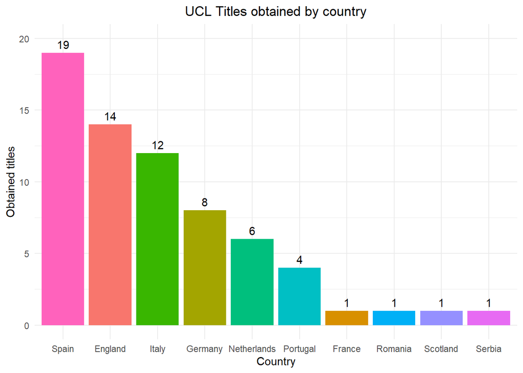

```r
ranking_by_country %>%
  ggplot(aes(x = reorder(Country, -Titles), y = Titles, fill = Country)) +
  geom_bar(stat = "identity", show.legend = FALSE) +
  geom_text(aes(label = Titles), vjust = -0.5) +
  labs(title = "UCL Titles obtained by country",
       x = "Country",
       y = "Obtained titles") +
  theme_minimal() +
  theme(plot.title = element_text(hjust = 0.5)) +
  ylim(0, 20)
```

> Hay una relación interesante entre la cantidad de títulos obtenidos por países y la cantidad de partidos que han jugado.

> Una posible explicación para este éxito es que España normalmente es uno de los países que más cupos directos tiene para entrar en la competencia. Esto significa que los equipos españoles tienen más oportunidades de participar en el torneo y, por lo tanto, más oportunidades de ganar.

> Además, debido a que los equipos españoles tienen más oportunidades de participar en el torneo, también han jugado muchos más partidos que los equipos de otros países. Esto les ha dado más experiencia y práctica en el torneo, lo que podría haber contribuido a su éxito.

> Es claro que existe una relación entre la cantidad de títulos obtenidos por países en la Champions League y la cantidad de partidos que han jugado. En el caso de España, su éxito en el torneo podría deberse en parte a que tiene más cupos directos para entrar en la competencia y, por lo tanto, ha jugado más partidos que otros países.

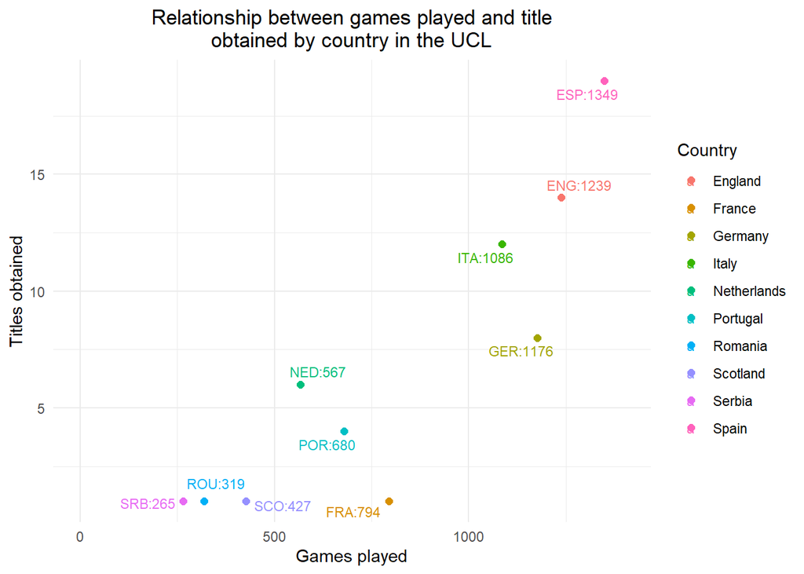

```r
country_abbreviations <- c(
  "England" = "ENG",
  "France" = "FRA",
  "Germany" = "GER",
  "Italy" = "ITA",
  "Netherlands" = "NED",
  "Portugal" = "POR",
  "Romania" = "ROU",
  "Scotland" = "SCO",
  "Serbia" = "SRB",
  "Spain" = "ESP"
)

# Agregar una nueva columna con las abreviaciones de los países

ranking_by_country <- ranking_by_country %>%
  mutate(Abb = country_abbreviations[Country]) %>%
  select(Abb, everything())

# Crear el gráfico con las etiquetas modificadas

ranking_by_country %>%
  ggplot(aes(x = Played, y = Titles, color = Country)) +
  geom_point(size = 2) +
  geom_text_repel(aes(label = paste(Abb, Played, sep = ":")), size = 3, force = 10) +
  scale_x_continuous(limits = c(0, ranking_by_country %>% summarise(max(Played)) %>% pull() + 50)) +
  labs(title = str_wrap("Relationship between games played and title obtained by country in the UCL", width = 50),
       x = "Games played",
       y = "Titles obtained") +
  theme_minimal() +
  theme(plot.title = element_text(hjust = 0.5))
```

> La razón principal de este éxito es el Real Madrid. Este equipo ha ganado un impresionante número de títulos de la Champions League, superando a cualquier otro equipo en la historia del torneo. Su dominio en el torneo es indiscutible, y su legado es algo digno de admiración. Cabe destacar que desde el cambio de formato de la competición, el Real Madrid ha ganado 8 títulos de la Champions League. Sin embargo, si sumamos todos los años desde que se creó la Liga de Campeones, el Real Madrid acumula un impresionante total de 14 títulos. Esto demuestra que el Real Madrid es un equipo representativo y exitoso en la historia de la Champions League.

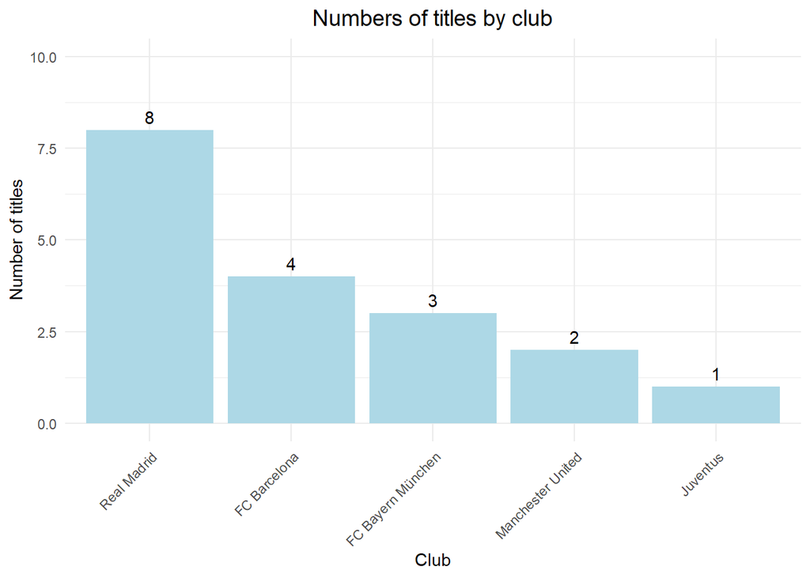

```r
ranking_by_club %>%
  filter(Pos >= 1 & Pos <= 5) %>%
  ggplot(aes(x = reorder(Club, -Titles), y = Titles)) +
  geom_bar(stat = "identity", fill = "lightblue") +
  geom_text(aes(label = Titles), vjust = -0.5) +
  scale_y_continuous(limits = c(0, 10)) +
  theme_minimal() +
  theme(axis.text.x = element_text(angle = 45, hjust = 1),
        plot.title = element_text(hjust = 0.5, size = 14)) +
  labs(title = "Numbers of titles by club",
       x = "Club",
       y = "Number of titles")
```

> Además de comparar el número de títulos de la Champions League, establecimos un criterio para comparar a los equipos que han estado más cerca de llegar a la final en los últimos 10 años. Este criterio estableció que se filtrasen aquellos equipos que hayan llegado por lo menos 7 veces a las instancias de cuartos de final en la última decada. Como resultado de este filtro se obtuvieron: Real Madrid, FC Barcelona, FC Bayern y Manchester City.

> A pesar de haber utilizado la última decada como criterio de selección de los equipos a comparar, en las siguientes gráficas se analizan las 5 temporadas en las que el Real Madrid ganó 4 veces la competición, siendo estas: 2013-2014 ; 2015-2016 ; 2016-2017 ; 2017-2018. Es importante resaltar que, para este análisis, se ha discriminado al Manchester City a pesar de cumplir con el criterio previamente establecido, ya que no clasificó a cuartos de final en 3 de esas 5 temporadas.

> Para visualizar el desempeño de estos equipos durante estas temporadas gloriosas del Real Madrid, podemos calcular los promedios de los goles anotados por partido y los goles recibidos por partido. Un promedio simple se calcula sumando todos los valores y dividiéndolos entre el número total de valores. En este caso, se sumarían todos los goles anotados y recibidos por cada equipo durante estas temporadas y se dividirían entre el número total de partidos jugados.

> Se decidió utilizar un promedio simple en lugar de un promedio ponderado porque es una medida más fácil de calcular y entender. Además, en este caso, todos los partidos tienen la misma importancia, por lo que no es necesario asignar pesos muestrales a cada partido. De esta manera, podemos obtener una medida clara y sencilla del desempeño de cada equipo en cuanto a goles anotados y recibidos.

> Al visualizar estos promedios, podremos ver cómo se comparan el Real Madrid, FC Barcelona y FC Bayern entre sí en cuanto a goles anotados y recibidos durante estas temporadas. Esto nos dará una idea más clara de su desempeño en el torneo y nos permitirá hacer comparaciones más precisas.

```r
Filt_UCL_Quarter_Finals <- UCL_Quarter_Finals %>%
  group_by(club) %>%
  summarize(count = n_distinct(year)) %>%
  filter(count >= 7) %>%
  inner_join(UCL_Quarter_Finals, by = "club") %>%
  filter(country %in% c("Spain", "Germany"))
```

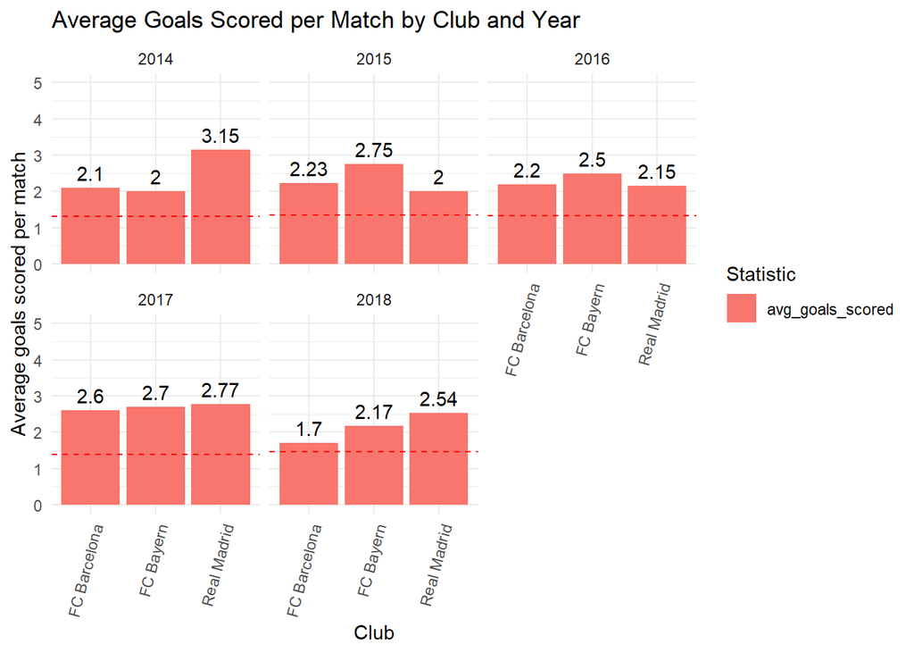

```r
Stats_Top_3 <- merge(Filt_UCL_Quarter_Finals, UCL_Stats, by.x = c("club", "year"), by.y = c("club", "year"))

# Filtrar la tabla para incluir solo los años que mencionas
Stats_Top_3_Filtered <- Stats_Top_3 %>%
  filter(year %in% c(2014, 2015, 2016, 2017, 2018))

# Agrupar el data frame por club y año
Stats_Top_3_Filtered <- Stats_Top_3_Filtered %>%
  group_by(club, year)

# Calcular el promedio simple de goles anotados y recibidos por partido
Stats_Top_3_Filtered <- Stats_Top_3_Filtered %>%
  summarize(avg_goals_scored = goals_scored / match_played,
            avg_goals_conceded = goals_conceded / match_played)

# Crear una tabla con las estadísticas que quieres mostrar en los gráficos
Stats_Top_3_Melted <- melt(Stats_Top_3_Filtered, id.vars = c("club", "year"), measure.vars = c("avg_goals_scored", "avg_goals_conceded"))

# Filtrar el data frame UCL_Stats para incluir solo los clubes que tienen datos para los años 2014 a 2018
UCL_Stats_Filtered <- UCL_Stats %>%
  filter(year %in% c(2014, 2015, 2016, 2017, 2018))

# Agrupar el data frame resultante por year
UCL_Stats_Filtered <- UCL_Stats_Filtered %>%
  group_by(year)

# Calcular el promedio simple de goles anotados y recibidos por partido para cada año
UCL_Stats_Filtered <- UCL_Stats_Filtered %>%
  summarize(avg_goals_scored = mean(goals_scored / match_played),
            avg_goals_conceded = mean(goals_conceded / match_played))

# Crear el primer gráfico de barras (promedio simple de goles anotados por partido)
ggplot(Stats_Top_3_Melted[Stats_Top_3_Melted$variable == "avg_goals_scored",], aes(x = club, y = value, fill = variable)) +
  geom_col(position = "dodge") +
  facet_wrap(~year) +
  geom_text(aes(label = round(value,2)), position=position_dodge(width=0.9), vjust=-0.5) +
  geom_hline(data=UCL_Stats_Filtered, aes(yintercept=avg_goals_scored), linetype="dashed", color="red") + # Agregamos una línea horizontal para el promedio simple de goles anotados por partido
   labs(x="Club", y="Average goals scored per match", fill="Statistic") +
   theme_minimal() +
   theme(axis.text.x = element_text(angle = 75, hjust = 1)) +
   scale_y_continuous(expand = expansion(mult = c(0.1,0.1))) +
   ylim(0,5) +
   ggtitle("Average Goals Scored per Match by Club and Year")
```

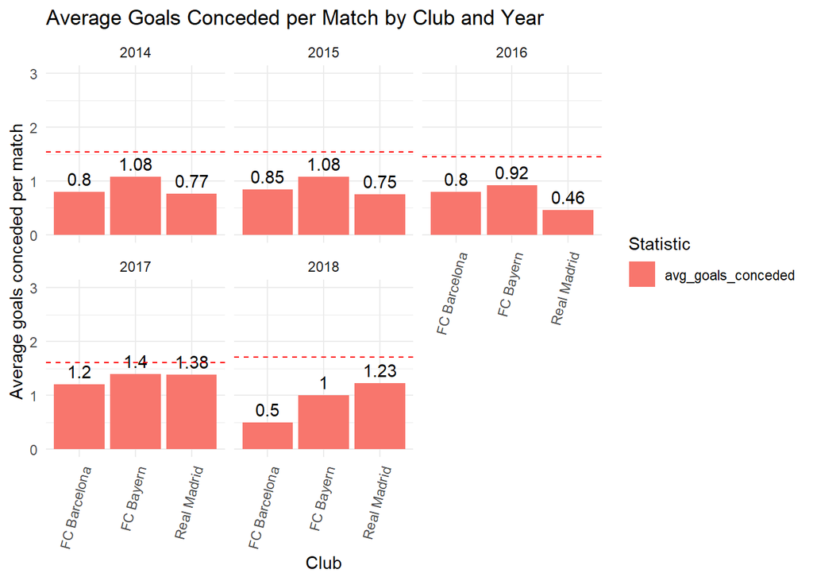

```r
# Crear el segundo gráfico de barras (promedio simple de goles recibidos por partido)
ggplot(Stats_Top_3_Melted[Stats_Top_3_Melted$variable == "avg_goals_conceded",], aes(x=club,y=value,fill=variable)) +
   geom_col(position="dodge") +
   facet_wrap(~year) +
   geom_text(aes(label=round(value,2)), position=position_dodge(width=0.9), vjust=-0.5) +
   geom_hline(data=UCL_Stats_Filtered,aes(yintercept=avg_goals_conceded), linetype="dashed", color="red") + # Agregamos una línea horizontal para el promedio simple de goles recibidos por partido
   labs(x="Club", y="Average goals conceded per match", fill="Statistic") +
   theme_minimal() +
   theme(axis.text.x = element_text(angle = 75,hjust=1)) +
   scale_y_continuous(expand=expansion(mult=c(0.1,0.1))) +
   ylim(0,3) +
   ggtitle("Average Goals Conceded per Match by Club and Year")
```

```r
reactable(Stats_Top_3_Filtered)
```

| club | year | avg_goals_scored | avg_goals_conceded |
| --- | --- | --- | --- |
| FC Barcelona | 2014 | 2.1 | 0.8 |
| FC Barcelona | 2015 | 2.23076923076923 | 0.846153846153846 |
| FC Barcelona | 2016 | 2.2 | 0.8 |
| FC Barcelona | 2017 | 2.6 | 1.2 |
| FC Barcelona | 2018 | 1.7 | 0.5 |
| FC Bayern | 2014 | 2 | 1.08333333333333 |
| FC Bayern | 2015 | 2.75 | 1.08333333333333 |
| FC Bayern | 2016 | 2.5 | 0.916666666666667 |
| FC Bayern | 2017 | 2.7 | 1.4 |
| FC Bayern | 2018 | 2.16666666666667 | 1 |

[output cut: 5 more lines]

[figure not shown]

[figure not shown]

> Tomando en cuenta que el Madrid ganó la competición en todas las temporadas menos en la 2014-2015, la cual ganó el Barcelona, en estas gráficas comparativas se puede observar que existe una estrecha relación entre el promedio de goles anotados y el promedio de goles recibidos y la capacidad para obtener el título de campeón, sin embargo, pudimos notar que en temporadas como la del 2017 y la del 2018 el Barcelona tuvo mejores promedios de goles recibidos, y en la temporada del 2016 el FC Bayern tuvo mejor promedio de goles anotados. Ya habiendo realizado este análisis podemos decir que el Real Madrid obtiene estadísticas acordes a sus títulos ganados en la mayoría de los casos a excepción de algunas temporadas en las cuales sus promedios fueron ligeramente menos favorables que los de sus rivales.

> Después de analizar las 5 temporadas en las que el Real Madrid ganó 4 veces la Champions League, podemos enfocarnos en la consecución del título más reciente en la temporada 2021-2022. Para ello, se mostrarán unas tablas en las que se podrá ver partido por partido, los resultados del Real Madrid, tanto en su estadio como de visitante.

> Estas tablas nos permitirán ver cómo el Real Madrid avanzó a través de las diferentes etapas del torneo y cómo se desempeñó en cada partido. Podremos ver sus victorias, empates y derrotas, así como los goles anotados y recibidos. Esto nos dará una idea más clara de cómo el Real Madrid logró ganar el título más reciente de la Champions League.

> Al comparar estos resultados con los resultados de las temporadas anteriores que analizamos anteriormente, podremos ver si hay similitudes o diferencias en el desempeño del Real Madrid. También podremos ver cómo el equipo ha evolucionado a lo largo de los años y cómo ha logrado mantener su éxito en el torneo.

> Al visualizar las tablas con los resultados del Real Madrid en la temporada 2021-2022, podremos entender mejor cómo el equipo logró ganar el título más reciente de la Champions League. Esto nos permitirá hacer conexiones con nuestro análisis anterior y ver cómo el éxito del Real Madrid en el torneo ha evolucionado a lo largo de los años.

```r
UCL_16_22_matches <- read_excel("UEFA Champions League 2016-2022 Data.xlsx",
                                sheet = "matches") %>%
  select(-"ATTENDANCE", -"PENALTY_SHOOT_OUT")

Matches_Away <- UCL_16_22_matches%>%
  filter(SEASON == "2021-2022",
         AWAY_TEAM == "Real Madrid")

UCL_16_22_matches <- UCL_16_22_matches %>%
  filter(SEASON == "2021-2022",
         HOME_TEAM == "Real Madrid")

UCL_16_22_matches <- rbind(UCL_16_22_matches, Matches_Away)

UCL_16_22_matches$DATE <- substr(UCL_16_22_matches$DATE_TIME, 1, 9)

UCL_16_22_matches$DATE <- as.Date(UCL_16_22_matches$DATE, format = "%d-%b-%y")
UCL_16_22_matches <- UCL_16_22_matches %>% arrange(DATE)

UCL_16_22_matches <- UCL_16_22_matches %>%
  select(-"DATE_TIME", -"MATCH_ID")

reactable(UCL_16_22_matches, filterable = TRUE, minRows = 10)
```

| SEASON | HOME_TEAM | AWAY_TEAM | STADIUM | HOME_TEAM_SCORE | AWAY_TEAM_SCORE | DATE |
| --- | --- | --- | --- | --- | --- | --- |
| 2021-2022 | Inter | Real Madrid | Giuseppe Meazza | 0 | 1 | 2021-09-15 |
| 2021-2022 | Real Madrid | FC Sheriff | Santiago Bernabéu | 1 | 2 | 2021-09-28 |
| 2021-2022 | Shakhtar Donetsk | Real Madrid | Olimpiyskyi | 0 | 5 | 2021-10-19 |
| 2021-2022 | Real Madrid | Shakhtar Donetsk | Santiago Bernabéu | 2 | 1 | 2021-11-03 |
| 2021-2022 | FC Sheriff | Real Madrid | Sheriff Stadium | 0 | 3 | 2021-11-24 |
| 2021-2022 | Real Madrid | Inter | Santiago Bernabéu | 2 | 0 | 2021-12-07 |
| 2021-2022 | Paris Saint-Germain | Real Madrid | Parc des Princes | 1 | 0 | 2022-02-15 |
| 2021-2022 | Real Madrid | Paris Saint-Germain | Santiago Bernabéu | 3 | 1 | 2022-03-09 |
| 2021-2022 | Chelsea FC | Real Madrid | Stamford Bridge | 1 | 3 | 2022-04-06 |
| 2021-2022 | Real Madrid | Chelsea FC | Santiago Bernabéu | 2 | 3 | 2022-04-12 |

[output cut: 3 more lines]

> En resumen, el Real Madrid tuvo un desempeño impresionante en la temporada 2021-2022, ganando la mayoría de sus partidos tanto como local como visitante. También lograron remontar en algunos partidos importantes y demostraron su habilidad para marcar goles y defender su portería.

[figure not shown]

## Conclusión:

> El objetivo de este informe era investigar las razones detrás del éxito del Real Madrid en la UEFA Champions League, una de las competiciones de fútbol más importantes y prestigiosas del mundo. Para ello, se utilizó una metodología cuantitativa que consistió en el análisis comparativo y estadístico de los datos del Real Madrid y otros equipos de fútbol que han participado en el torneo en la última década. Se utilizaron diversas fuentes de datos, librerías y técnicas para manipular, visualizar y analizar los datos, como knitr, tidyverse, ggplot2, reactable, entre otras. Se presentaron tablas, gráficas y textos explicativos para comunicar los resultados del análisis.

> Los principales hallazgos del informe fueron los siguientes:

> El Real Madrid ha sido el equipo más exitoso en la historia de la Champions League, habiendo ganado 14 títulos en total y 5 en la última década.

> El Real Madrid ha demostrado una gran capacidad para superar situaciones adversas y lograr victorias importantes en partidos decisivos, lo que le ha permitido avanzar a través de las diferentes etapas del torneo y ganar el título.

> El Real Madrid ha contado con una plantilla de gran calidad, compuesta por algunos de los mejores jugadores del mundo, así como con entrenadores de primer nivel que han sido capaces de desarrollar estrategias efectivas y adaptarse a diferentes situaciones y oponentes.

> Algunas recomendaciones que se pueden derivar de este informe son las siguientes:

> Para los equipos que quieran competir con el Real Madrid o aspirar a ganar la Champions League, es importante contar con una plantilla de jugadores talentosos y experimentados, así como con un entrenador capaz de diseñar e implementar un plan de juego adecuado para cada partido.

> Para los equipos que quieran mejorar su rendimiento en la Champions League, es importante analizar sus propias estadísticas y las de sus rivales, identificar sus fortalezas y debilidades, y determinar las áreas en las que podrían mejorar.

> Para los aficionados al fútbol y al análisis estadístico del deporte, es interesante seguir el desarrollo de la Champions League y observar cómo el Real Madrid y otros equipos evolucionan a lo largo del torneo. También es recomendable utilizar herramientas como knitr, tidyverse, ggplot2, reactable, entre otras, para crear informes dinámicos e interactivos que permitan comunicar los resultados del análisis de forma clara y atractiva.

> Algunas limitaciones que se pueden reconocer en este informe son las siguientes:

> El informe se basa en datos históricos de la Champions League y no toma en cuenta otros factores que podrían influir en el éxito del Real Madrid o de otros equipos, como el estado físico o mental de los jugadores, las condiciones climáticas o ambientales de los partidos, o las decisiones arbitrales.

> El informe se enfoca en el análisis cuantitativo de los datos y no profundiza en el análisis cualitativo o interpretativo de los mismos. Por ejemplo, no se explora el estilo o la filosofía de juego del Real Madrid o de otros equipos, ni se analiza el impacto social o cultural que tiene el éxito del Real Madrid o de otros equipos en sus respectivos países o regiones.

> El informe se limita a comparar al Real Madrid con algunos equipos seleccionados según un criterio establecido previamente. Sin embargo, hay otros equipos que también han participado en la Champions League y que podrían ofrecer datos interesantes o relevantes para el análisis. Por ejemplo, se podría comparar al Real Madrid con equipos que han sido sus rivales históricos o que han tenido un desempeño destacado en alguna temporada.

> Esperamos que este informe haya sido de su interés y le haya ayudado a comprender mejor el éxito del Real Madrid en la UEFA Champions League.

## Recursos empleados:

- https://www.kaggle.com/datasets/basharalkuwaiti/champions-league-era-stats?select=TopGoalScorer.csv
- https://www.kaggle.com/datasets/sarangpurandare/uefa-champions-league-player-statistics
- https://www.kaggle.com/datasets/johnharshith/uefa-champions-league-quarter-finals-since-1980
- https://www.kaggle.com/datasets/cbxkgl/uefa-champions-league-2016-2022-data
- https://www.kaggle.com/datasets/bakar31/ucl-statistics
- https://www.kaggle.com/code/bakar31/ucl-stats-analysis
- https://www.kaggle.com/datasets/azminetoushikwasi/ucl-202122-uefa-champions-league
- https://www.kaggle.com/datasets/elvinagammed/the-champions-league?resource=download
- https://www.kaggle.com/code/elvinagammed/starter-the-champions-league-89f032cd-3/input